# Chartmetric Data Analytics Intern - Take Home Test

## Author: Rebecca Seifert

## Published: 2025.03.27

## SQL

Figure 1 - Diagram of Given Schema Details

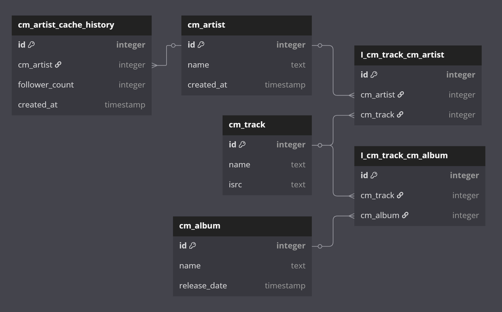

```python
from IPython.display import Image, display
image_path = "/content/drive/MyDrive/Colab Notebooks/rjs_Chartmetric_takehometest-schema.png"
display(Image(image_path))
```

### Question 1

Write a query to retrieve the artist names along with the total number of tracks each artist has, sorted in descending order of the number of tracks.

```
SELECT distinct name as ArtistName,
       count(cm_track) as TotalNumberOfTracks
FROM I_cm_track_cm_artist
     LEFT JOIN cm_artist on I_cm_track_cm_artist.cm_artist=cm_artist.id
GROUP BY cm_artist
ORDER BY TotalNumberOfTracks desc
```

### Question 2

Write a query to find the artist names along with the total number of tracks each artist has and the release year of their earliest album, sorted by artist name.

```
SELECT distinct cm_artist.name as ArtistName,
       count(I_cm_track_cm_artist.cm_track) as TotalNumberOfTracks,
       year(min(cm_album.release_date)) as EarliestAlbumReleaseYear
FROM I_cm_track_cm_artist
     LEFT JOIN cm_artist on I_cm_track_cm_artist.cm_artist=cm_artist.id
     LEFT JOIN cm_track on I_cm_track_cm_artist.cm_track=cm_track.id
     LEFT JOIN I_cm_track_cm_album on cm_track.id=I_cm_track_cm_album.cm_track
     LEFT JOIN cm_album on I_cm_track_cm_album.cm_album=cm_album.id
GROUP BY ArtistName
ORDER BY ArtistName
```

### Question 3

Implement a query to find the track names that have been associated with multiple artists, along with the names of those artists.

```
SELECT distinct cm_track.name as TrackName,
       GROUP_CONCAT(cm_artist.name SEPARATOR "*italicized text*, ") as Artists
FROM I_cm_track_cm_artist
     LEFT JOIN cm_track on I_cm_track_cm_artist.cm_track=cm_track.id
     LEFT JOIN cm_artist on I_cm_track_cm_artist.cm_artist=cm_artist.id
GROUP BY cm_track
HAVING count(I_cm_track_cm_artist.cm_artist) > 1
ORDER BY TrackName
```

### Bonus

Write a query to find the artist names along with the average follower count and the running total of follower counts for each artist from the `cm_artist_cache_history` table.

```
WITH temp AS (SELECT cm_artist.name as ArtistName,
                     cm_artist_cache_history.cm_artist as ArtistID,
                     TRUNCATE(AVG(follower_count), 2) as AverageFollowerCount
              FROM cm_artist_cache_history
                   LEFT JOIN cm_artist on cm_artist_cache_history.cm_artist=cm_artist.id
              GROUP BY ArtistName, ArtistID
              ORDER BY ArtistName, ArtistID
             )
SELECT ArtistName,
       AverageFollowerCount,
       sum(AverageFollowerCount) over (order by ArtistName, ArtistID) as RunningTotal
FROM temp
ORDER BY ArtistName, ArtistID
```

## Python

Python Set Up

```python
#Google colab requires reinstall for every new runtime instance
!pip install Groq

# Import necessary libraries
import base64
from groq import Groq
import io
import json
import math
import matplotlib.pyplot as plt
import os
import pandas as pd
from scipy.stats import pearsonr
from matplotlib import style
import plotly.express as px
import requests
from google.colab import userdata
```

```
Downloading groq-0.20.0-py3-none-any.whl (124 kB)
   ━━━━━━━━━━━━━━━━━━━━━━━━━━━━━━━━━━━━━━━━ 124.9/124.9 kB 5.7 MB/s eta 0:00:00
```

### Basic Data Manipulation

1. Load the dataset into a `pandas` DataFrame.
2. Calculate the summary statistics (mean, median, min, max) for the `YOUTUBE_VIEWS` column.

```python
# Load the dataset into a DataFrame
Dataset = pd.read_csv("/content/drive/MyDrive/Colab Notebooks/Dataset.csv",
                   encoding="iso-8859-1") #This is not the correct encoding, but I have tried 8 of the most common ones, none of which were correct. I would default to UTF-8, but it throws an error, and ISO-8859-1 is at least mostly correct (apologies to Michael Buble).

# Create a copy to avoid inadvertent changes to original dataset
dm = Dataset.copy()

# Calculate and print summary statistics for YOUTUBE_VIEWS
print("The mean of YOUTUBE_VIEWS is " + str(math.trunc(dm.YOUTUBE_VIEWS.mean()))+".")
print("The median of YOUTUBE_VIEWS is " + str(math.trunc(dm.YOUTUBE_VIEWS.median()))+".")
print("The min of YOUTUBE_VIEWS is " + str(math.trunc(dm.YOUTUBE_VIEWS.min()))+".")
print("The max of YOUTUBE_VIEWS is " + str(math.trunc(dm.YOUTUBE_VIEWS.max()))+".")
```

```
The mean of YOUTUBE_VIEWS is 14357394.
The median of YOUTUBE_VIEWS is 738280.
The min of YOUTUBE_VIEWS is 10.
The max of YOUTUBE_VIEWS is 1255991515.
```

The summary statistics for `YOUTUBE_VIEWS` are displayed above.

### Data Cleaning

In a separate DataFrame: For every distinct `CM_ID`, find the corresponding `SPOTIFY_PLAYS`, `SPOTIFY_POPULARITY`, `TIKTOK_TOP_VIDEOS_VIEWS`, and `AIRPLAY_STREAMS`.

1. Remove any duplicate rows from the dataset.
2. Filter out rows where the `SPOTIFY_POPULARITY` is less than 10.

```python
# Create a copy to avoid inadvertent changes to original dataset
dc = Dataset.copy()
# Remove records that don"t have an ID since they won"t be usable in next step
dc = dc.dropna(subset=["CM_ID"])
# Correct CM_ID type to string rather than float since it"s an ID value
dc["CM_ID"] = dc["CM_ID"].astype(int).astype(str)
# Match the metric values to unique CM_ID
dc = dc.groupby(["CM_ID"]).agg(
    {
    "SPOTIFY_PLAYS": "mean",
    "SPOTIFY_POPULARITY": "mean",
    "TIKTOK_TOP_VIDEOS_VIEWS": "mean",
    "AIRPLAY_STREAMS": "mean"
    }
)
# Reset index after group_by()
dc = dc.reset_index()
# Sort data frame by CM_ID (alphabetically since CM_ID is string)
dc = dc.sort_values(by="CM_ID")

# [1.] Remove duplicates (across all columns, including CM_ID)
dc = dc.drop_duplicates() #This should not do anything since there should be no duplicates after applying groupby().

# [2.] Remove rows with SPOTIFY_POPULARITY < 10
dc = dc[dc["SPOTIFY_POPULARITY"] >= 10]

# Display first 5 rows of cleaned DataFrame
dc.head()
```

|  | CM_ID | SPOTIFY_PLAYS | SPOTIFY_POPULARITY | TIKTOK_TOP_VIDEOS_VIEWS | AIRPLAY_STREAMS |
| --- | --- | --- | --- | --- | --- |
| 0 | 100008540 | 438051.0 | 37.0 | NaN | NaN |
| 1 | 100016452 | 666143.0 | 41.0 | 181256.0 | 3.0 |
| 2 | 100019821 | 20513.0 | 11.0 | NaN | NaN |
| 3 | 100020825 | 19826.0 | 19.0 | NaN | 2.0 |
| 4 | 100020826 | 106267.0 | 31.0 | NaN | 3.0 |

The first 5 rows of the cleaned data are displayed above.

Technically, the method employed above relies on the mean being the correct value for `SPOTIFY_PLAYS`, `SPOTIFY_POPULARITY`, `TIKTOK_TOP_VIDEOS_VIEWS`, and `AIRPLAY_STREAMS`. This will work well for records that have simply been duplicated. If there are records with the same `CM_ID` and conflicting values, they are still averaged, and this is therefore potentially creating bad/unreliable values, depending on what the contextually appropriate method for handling these conflicts should be (e.g. first value, latest value, weighted average, de-duplicated unweighted average, etc).

### Data Exploration

1. What are the top 5 tracks with the highest `SPOTIFY_PLAYS`?
2. Plot a stacked bar chart for the track with the highest increase in `AIRPLAY_STREAMS` in a months time. The stack would include the actual value and the monthly difference percentage value.

```python
# Create a copy to avoid inadvertent changes to original dataset
de = Dataset.copy()

# Match the metric values to unique Track, Artist, and ISRC
de = de.groupby(["TRACK_NAME", "ARTIST_NAME", "ISRC"]).agg(
    {
    "UPC": "first",
    "ALBUM_NAME": "first",
    "CM_ID": "first",
    "YOUTUBE_VIEWS": "mean",
    "YOUTUBE_LIKES": "mean",
    "YOUTUBE_COMMENTS": "mean",
    "SOUNDCLOUD_PLAYS": "mean",
    "SPOTIFY_PLAYS": "mean",
    "SPOTIFY_POPULARITY": "mean",
    "SHAZAM_COUNT": "mean",
    "GENIUS_PAGEVIEWS": "mean",
    "TIKTOK_POSTS": "mean",
    "TIKTOK_TOP_VIDEOS_LIKES": "mean",
    "TIKTOK_TOP_VIDEOS_VIEWS": "mean",
    "PANDORA_LIFETIME_STREAMS": "mean",
    "AIRPLAY_STREAMS": "mean",
    "SIRIUSXM_STREAMS": "mean",
    "CM_TRACK_RANK": "mean",
    "TIDAL_POPULARITY": "mean",
    "YOUTUBE_VIEWS_WEEKLY_DIFF_PER": "mean",
    "YOUTUBE_LIKES_WEEKLY_DIFF_PER": "mean",
    "YOUTUBE_COMMENTS_WEEKLY_DIFF_PER": "mean",
    "SOUNDCLOUD_PLAYS_WEEKLY_DIFF_PER": "mean",
    "SPOTIFY_PLAYS_WEEKLY_DIFF_PER": "mean",
    "SPOTIFY_POPULARITY_WEEKLY_DIFF_PER": "mean",
    "SHAZAM_COUNT_WEEKLY_DIFF_PER": "mean",
    "GENIUS_PAGEVIEWS_WEEKLY_DIFF_PER": "mean",
    "TIKTOK_POSTS_WEEKLY_DIFF_PER": "mean",
    "TIKTOK_TOP_VIDEOS_LIKES_WEEKLY_DIFF_PER": "mean",
    "TIKTOK_TOP_VIDEOS_VIEWS_WEEKLY_DIFF_PER": "mean",
    "PANDORA_LIFETIME_STREAMS_WEEKLY_DIFF_PER": "mean",
    "AIRPLAY_STREAMS_WEEKLY_DIFF_PER": "mean",
    "SIRIUSXM_STREAMS_WEEKLY_DIFF_PER": "mean",
    "CM_TRACK_RANK_WEEKLY_DIFF_PER": "mean",
    "TIDAL_POPULARITY_WEEKLY_DIFF_PER": "mean",
    "YOUTUBE_VIEWS_MONTHLY_DIFF_PER": "mean",
    "YOUTUBE_LIKES_MONTHLY_DIFF_PER": "mean",
    "YOUTUBE_COMMENTS_MONTHLY_DIFF_PER": "mean",
    "SOUNDCLOUD_PLAYS_MONTHLY_DIFF_PER": "mean",
    "SPOTIFY_PLAYS_MONTHLY_DIFF_PER": "mean",
    "SPOTIFY_POPULARITY_MONTHLY_DIFF_PER": "mean",
    "SHAZAM_COUNT_MONTHLY_DIFF_PER" : "mean",
    "GENIUS_PAGEVIEWS_MONTHLY_DIFF_PER": "mean",
    "TIKTOK_POSTS_MONTHLY_DIFF_PER": "mean",
    "TIKTOK_TOP_VIDEOS_LIKES_MONTHLY_DIFF_PER": "mean",
    "TIKTOK_TOP_VIDEOS_VIEWS_MONTHLY_DIFF_PER": "mean",
    "PANDORA_LIFETIME_STREAMS_MONTHLY_DIFF_PER": "mean",
    "AIRPLAY_STREAMS_MONTHLY_DIFF_PER": "mean",
    "SIRIUSXM_STREAMS_MONTHLY_DIFF_PER": "mean",
    "CM_TRACK_RANK_MONTHLY_DIFF_PER": "mean",
    "TIDAL_POPULARITY_MONTHLY_DIFF_PER": "mean"
    }
)

# Match the metric values to unique Track and Artist
de = de.groupby(["TRACK_NAME", "ARTIST_NAME"]).agg(
    {
    "UPC": "first",
    "ALBUM_NAME": "first",
    "CM_ID": "first",
    "YOUTUBE_VIEWS": "sum",
    "YOUTUBE_LIKES": "sum",
    "YOUTUBE_COMMENTS": "sum",
    "SOUNDCLOUD_PLAYS": "sum",
    "SPOTIFY_PLAYS": "sum",
    "SPOTIFY_POPULARITY": "mean",
    "SHAZAM_COUNT": "sum",
    "GENIUS_PAGEVIEWS": "sum",
    "TIKTOK_POSTS": "sum",
    "TIKTOK_TOP_VIDEOS_LIKES": "sum",
    "TIKTOK_TOP_VIDEOS_VIEWS": "sum",
    "PANDORA_LIFETIME_STREAMS": "sum",
    "AIRPLAY_STREAMS": "sum",
    "SIRIUSXM_STREAMS": "sum",
    "CM_TRACK_RANK": "mean",
    "TIDAL_POPULARITY": "mean",
    "YOUTUBE_VIEWS_WEEKLY_DIFF_PER": "mean",
    "YOUTUBE_LIKES_WEEKLY_DIFF_PER": "mean",
    "YOUTUBE_COMMENTS_WEEKLY_DIFF_PER": "mean",
    "SOUNDCLOUD_PLAYS_WEEKLY_DIFF_PER": "mean",
    "SPOTIFY_PLAYS_WEEKLY_DIFF_PER": "mean",
    "SPOTIFY_POPULARITY_WEEKLY_DIFF_PER": "mean",
    "SHAZAM_COUNT_WEEKLY_DIFF_PER": "mean",
    "GENIUS_PAGEVIEWS_WEEKLY_DIFF_PER": "mean",
    "TIKTOK_POSTS_WEEKLY_DIFF_PER": "mean",
    "TIKTOK_TOP_VIDEOS_LIKES_WEEKLY_DIFF_PER": "mean",
    "TIKTOK_TOP_VIDEOS_VIEWS_WEEKLY_DIFF_PER": "mean",
    "PANDORA_LIFETIME_STREAMS_WEEKLY_DIFF_PER": "mean",
    "AIRPLAY_STREAMS_WEEKLY_DIFF_PER": "mean",
    "SIRIUSXM_STREAMS_WEEKLY_DIFF_PER": "mean",
    "CM_TRACK_RANK_WEEKLY_DIFF_PER": "mean",
    "TIDAL_POPULARITY_WEEKLY_DIFF_PER": "mean",
    "YOUTUBE_VIEWS_MONTHLY_DIFF_PER": "mean",
    "YOUTUBE_LIKES_MONTHLY_DIFF_PER": "mean",
    "YOUTUBE_COMMENTS_MONTHLY_DIFF_PER": "mean",
    "SOUNDCLOUD_PLAYS_MONTHLY_DIFF_PER": "mean",
    "SPOTIFY_PLAYS_MONTHLY_DIFF_PER": "mean",
    "SPOTIFY_POPULARITY_MONTHLY_DIFF_PER": "mean",
    "SHAZAM_COUNT_MONTHLY_DIFF_PER" : "mean",
    "GENIUS_PAGEVIEWS_MONTHLY_DIFF_PER": "mean",
    "TIKTOK_POSTS_MONTHLY_DIFF_PER": "mean",
    "TIKTOK_TOP_VIDEOS_LIKES_MONTHLY_DIFF_PER": "mean",
    "TIKTOK_TOP_VIDEOS_VIEWS_MONTHLY_DIFF_PER": "mean",
    "PANDORA_LIFETIME_STREAMS_MONTHLY_DIFF_PER": "mean",
    "AIRPLAY_STREAMS_MONTHLY_DIFF_PER": "mean",
    "SIRIUSXM_STREAMS_MONTHLY_DIFF_PER": "mean",
    "CM_TRACK_RANK_MONTHLY_DIFF_PER": "mean",
    "TIDAL_POPULARITY_MONTHLY_DIFF_PER": "mean"
    }
)
```

Inspection of the dataset suggests that repeated rows differ by `UPC` and/or spelling of `ALBUM_NAME`, but the quantitative metrics appear mostly duplicated where values of `TRACK_NAME`, `ARTIST_NAME`, and `ISRC` are the same.

Thus, the data is consolidated in two steps. First, the records are aggregated by `TRACK_NAME`, `ARTIST_NAME`, and `ISRC`, using means for all numeric values. This attempts to find the "true" value for each recording (`ISRC` is the unique identifier for recordings). Then, these means are summed for the actual numeric values and averaged for the percentage numeric values across `TRACK_NAME` and `ARTIST_NAME`. This attempts to approximate the total number of streams/plays and the overall monthly/weekly percentage increases/decreases, grouping together all recordings of each track.

Ideally, context and knowledge of the data collection process/sources should inform deduplication. If album-level information is of interest, the analysis could easily be tweaked to include `ALBUM_NAME` or another variable in the `group_by()` criteria.

```python
# [1.]
de = de.sort_values(by="SPOTIFY_PLAYS", ascending=False)
de[["SPOTIFY_PLAYS"]][0:5]
```

[output not shown]

The top 5 tracks with the highest `SPOTIFY_PLAYS` are displayed above.

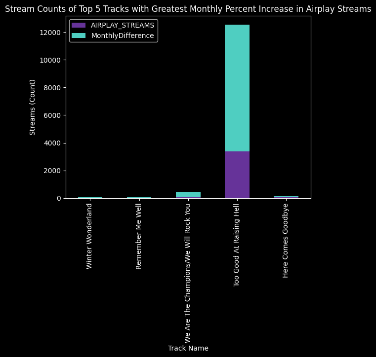

```python
# [2.]
de = de.sort_values(by="AIRPLAY_STREAMS_MONTHLY_DIFF_PER", ascending=False)
de = de.iloc[0:5]
de = de.reset_index()
de["MonthlyDifference"] = de["AIRPLAY_STREAMS"]*(de["AIRPLAY_STREAMS_MONTHLY_DIFF_PER"]/100)

plt.style.use('dark_background')
de.plot(x="TRACK_NAME",
        y=["AIRPLAY_STREAMS", "MonthlyDifference"],
        kind="bar",
        stacked=True,
        title="Stream Counts of Top 5 Tracks with Greatest Monthly Percent Increase in Airplay Streams",
        color=["#663399", "#4FCEC1"])
plt.xlabel("Track Name")
plt.ylabel("Streams (Count)")
plt.show()

#fig = px.bar(de,
#             x="TRACK_NAME",
#             y=["AIRPLAY_STREAMS", "MonthlyDifference"],
#             barmode = "stack",
#             labels={"TRACK_NAME": "Track Name",
#                     "AIRPLAY_STREAMS": "Initial Streams (Count)",
#                     "MonthlyDifference": "Additional Streams (Count)"
#                     },
#             title="Stream Counts of Top 5 Tracks with Greatest Monthly Percent Increase in Airplay Streams",
#             template="plotly_dark")
#fig.update_layout(
#    font_family="Raleway",
#    font_color="#111111",
#    title_font_family="Raleway",
#    title_font_color="#111111",
#    legend_title_font_color="#111111"
#)
#fig.update_xaxes(title_font_family="Raleway")
#fig.show()
```

Transparently, I was kind of confused by the instructions here, so I made a lot of assumptions/educated guesses about what was being asked. With no data dictionary (there was a Notion link? in the pdf, but it was not public/accessible), I was unsure what the variables were exactly.

As written, I read the request as a stacked bar chart for the one track with the highest monthly differential in `AIRPLAY_STREAMS`, where the stack is made up of the absolute number of streams and the percentage monthly differential. This did not make sense since monthly values for `AIRPLAY_STREAMS` are not given, as far as I could tell, and it is bad practice to mix scales in a bar chart, especially within a stacked column.

Instead, the plot above displays the "base" `AIRPLAY_STREAMS` count and the adjusted monthly growth as a count value for the top 5 tracks sorted by `AIRPLAY_STREAMS_MONTHLY_DIFF_PER`. The adjusted monthly growth is found by assuming the `AIRPLAY_STREAMS_MONTHLY_DIFF_PER` represents the growth in the last month as a percentage of `AIRPLAY_STREAMS`.

Interestingly, "Too Good at Raising Hell" has substantial growth given its relatively high existing stream count. The other 4 of the top 5 tracks have relatively low stream counts, which might be expected as their percentage growth is likely to be greater the lower the stream count is, i.e. an increase from 2 to 10 streams would not be very extreme or uncommon but constitutes a 400% growth.

### Data Aggregation

1. Calculate the total streams for each album. Albums have a unique identifier called `UPC`. After calculating the total streams, find the difference of total streams for each album from the average of each album.
2. Calculate the average `YOUTUBE_VIEWS` for each album.

```python
# Create a copy to avoid inadvertent changes to original dataset
da = Dataset.copy()

# Match the metric values to unique UPC and Track
da = da.groupby(["UPC", "TRACK_NAME"]).agg(
    {
    "ALBUM_NAME": "first",
    "YOUTUBE_VIEWS": "mean",
    "SOUNDCLOUD_PLAYS": "mean",
    "SPOTIFY_PLAYS": "mean",
    "SHAZAM_COUNT": "mean",
    "TIKTOK_TOP_VIDEOS_VIEWS": "mean",
    "PANDORA_LIFETIME_STREAMS": "mean",
    "AIRPLAY_STREAMS": "mean",
    "SIRIUSXM_STREAMS": "mean"
    }
)

da["AverageYouTube"] = da["YOUTUBE_VIEWS"]
da["AverageStreams"] = da.sum(axis=1, numeric_only=True)
da["TotalStreams"] = da.sum(axis=1, numeric_only=True)

# Match the metric values to unique UPC
da = da.groupby(["UPC"]).agg(
    {
    "ALBUM_NAME": "first",
    "YOUTUBE_VIEWS": "sum",
    "SOUNDCLOUD_PLAYS": "sum",
    "SPOTIFY_PLAYS": "sum",
    "SHAZAM_COUNT": "sum",
    "TIKTOK_TOP_VIDEOS_VIEWS": "sum",
    "PANDORA_LIFETIME_STREAMS": "sum",
    "AIRPLAY_STREAMS": "sum",
    "SIRIUSXM_STREAMS": "sum",
    "AverageYouTube": "mean",
    "AverageStreams": "mean",
    "TotalStreams": "sum"
    }
)

# Calculate difference between total and average count of streams
da["Difference"] = da["TotalStreams"] - da["AverageStreams"]

# Display [1.] and [2.]
da[["TotalStreams", "Difference", "AverageYouTube"]].head()
```

| UPC | TotalStreams | Difference | AverageYouTube |
| --- | --- | --- | --- |
| 4.400375e+10 | 20159782.0 | 1.924343e+07 | 1.827583e+06 |
| 4.400376e+10 | 338527838.0 | 3.255075e+08 | 1.277880e+07 |
| 4.400380e+10 | 54672832.0 | 5.218770e+07 | 1.191094e+06 |
| 8.439300e+10 | 43717298.0 | 4.189574e+07 | 4.914200e+04 |
| 8.439300e+10 | 0.0 | 0.000000e+00 | NaN |

The first 5 rows for the requested columns of the aggregated data are displayed above. `TotalStreams` represents the total streams for each album. `Difference` represents the difference of total streams for each album from the average of each album. `AverageYouTube` represents the average `YOUTUBE_VIEWS` for each album.

### Statistical Analysis

1. Perform a correlation analysis between `YOUTUBE_VIEWS` and `SPOTIFY_PLAYS`.
2. Create a unique ranking system for the artists to have one rank which is defined by track metrics given in the dataset. The final data should be a table having columns: `ARTIST_NAME`, `RANK`. Please explain your methodology - there is no right answer here.

```python
# [1.] Set up for correlation analysis

# Create a copy to avoid inadvertent changes to original dataset
sa = Dataset.copy()

# Match the metric values to unique Track, Artist, and ISRC
sa = sa.groupby(["TRACK_NAME", "ARTIST_NAME", "ISRC"]).agg(
    {
    "UPC": "first",
    "ALBUM_NAME": "first",
    "CM_ID": "first",
    "YOUTUBE_VIEWS": "mean",
    "SPOTIFY_PLAYS": "mean"
    }
)

# Match the metric values to unique Track and Artist
sa = sa.groupby(["TRACK_NAME", "ARTIST_NAME"]).agg(
    {
    "UPC": "first",
    "ALBUM_NAME": "first",
    "CM_ID": "first",
    "YOUTUBE_VIEWS": "sum",
    "SPOTIFY_PLAYS": "sum"
    }
)
```

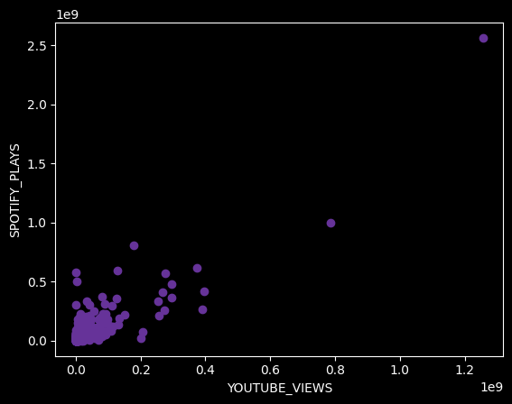

```python
# [1.] Check for linear relationship

# Create a scatter plot
plt.style.use('dark_background')
plt.scatter(sa["YOUTUBE_VIEWS"],
            sa["SPOTIFY_PLAYS"],
            color="#663399")
plt.xlabel("YOUTUBE_VIEWS")
plt.ylabel("SPOTIFY_PLAYS")
plt.show()
```

Assumption failed: To perform a correlation analysis, the variables of interest should have a roughly linear relationship with no major outliers. The cluster in the lower left corner and the extreme values to the top right of the graph displayed above shows that the variables do not have a roughly linear relationship and there are outliers.

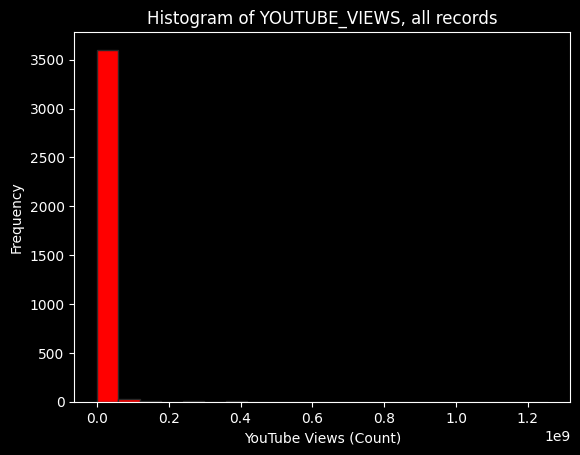

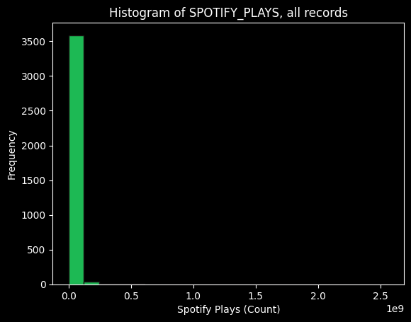

```python
# [1.] Check for normality of variables

# Plot a histogram of YOUTUBE_VIEWS
plt.style.use('dark_background')
plt.hist(sa["YOUTUBE_VIEWS"], bins=21, color="#FF0000", edgecolor="#282828")
plt.title("Histogram of YOUTUBE_VIEWS, all records")
plt.xlabel("YouTube Views (Count)")
plt.ylabel("Frequency")
plt.show()

# Plot a histogram of YOUTUBE_VIEWS
plt.style.use('dark_background')
plt.hist(sa["SPOTIFY_PLAYS"], bins=21, color="#1DB954", edgecolor="#191414")
plt.title("Histogram of SPOTIFY_PLAYS, all records")
plt.xlabel("Spotify Plays (Count)")
plt.ylabel("Frequency")
plt.show()
```

Assumption (mostly) failed: To perform a correlation analysis, the variables of interest should have be roughly normally distributed. The very heavy right skew of the graphs displayed above shows that the variables are not roughly normally distributed. In some contexts however, the analysis could still be reasonable provided the other assumptions are reasonable.

```python
# [1.] Analyze correlation

# Calculate Pearson's correlation coefficient and p-value
corr_var1_var2, p_var1_var2 = pearsonr(sa["YOUTUBE_VIEWS"], sa["SPOTIFY_PLAYS"])
print(f"\nCorrelation between YOUTUBE_VIEWS and SPOTIFY_PLAYS: {corr_var1_var2:.2f}, p-value: {p_var1_var2:.3f}")
```

```
Correlation between YOUTUBE_VIEWS and SPOTIFY_PLAYS: 0.88, p-value: 0.000
```

The calculated Pearson correlation coefficient, r, is 0.88 with a p-value of 0.000. If the analysis were valid, i.e. the assumptions were reasonable, this would mean there is a statistically significant (at the alpha=0.01 level) linear relationship between `YOUTUBE_VIEWS` and `SPOTIFY_PLAYS` that explains approximately 77% of the variability in the data.

```python
# [1.] Remove extreme values to reattempt correlation analysis

# Remove extreme values
sa = sa[sa["YOUTUBE_VIEWS"] > 0]
sa = sa[sa["SPOTIFY_PLAYS"] > 0]
sa = sa[sa["YOUTUBE_VIEWS"] < 500000]
sa = sa[sa["SPOTIFY_PLAYS"] < 500000]
```

Since the previous analysis was not valid due to failed assumptions, I reduce the scope of the data and attempt the analysis anew.

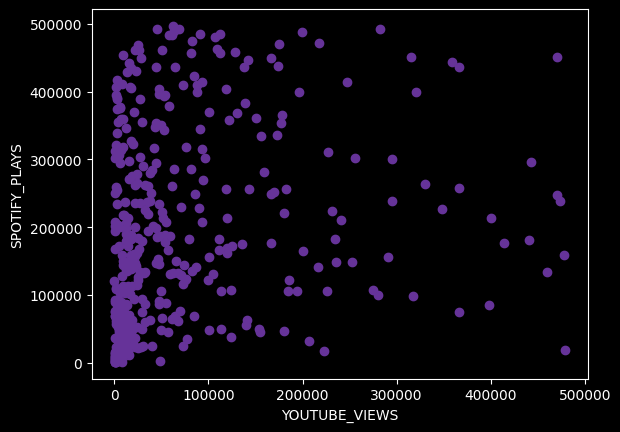

```python
# [1.] Check for linear relationship

# Create a scatter plot
plt.style.use('dark_background')
plt.scatter(sa["YOUTUBE_VIEWS"],
            sa["SPOTIFY_PLAYS"],
            color="#663399")
plt.xlabel("YOUTUBE_VIEWS")
plt.ylabel("SPOTIFY_PLAYS")
plt.show()
```

Assumption failed: To perform a correlation analysis, the variables of interest should have a roughly linear relationship with no major outliers. The random scattering throughout the graph displayed above shows that the variables do not have a roughly linear relationship. There are no obvious outliers though, so that assumption is reasonable.

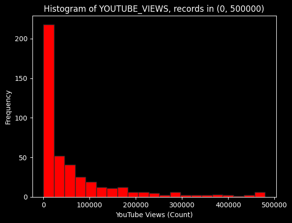

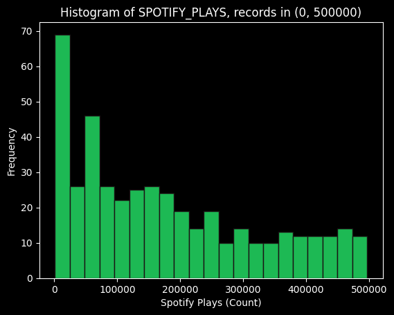

```python
# [1.] Check for normality of variables

# Plot a histogram of YOUTUBE_VIEWS
plt.style.use('dark_background')
plt.hist(sa["YOUTUBE_VIEWS"], bins=21, color="#FF0000", edgecolor="#282828")
plt.title("Histogram of YOUTUBE_VIEWS, records in (0, 500000)")
plt.xlabel("YouTube Views (Count)")
plt.ylabel("Frequency")
plt.show()

# Plot a histogram of YOUTUBE_VIEWS
plt.style.use('dark_background')
plt.hist(sa["SPOTIFY_PLAYS"], bins=21, color="#1DB954", edgecolor="#191414")
plt.title("Histogram of SPOTIFY_PLAYS, records in (0, 500000)")
plt.xlabel("Spotify Plays (Count)")
plt.ylabel("Frequency")
plt.show()
```

Assumption (mostly) failed: To perform a correlation analysis, the variables of interest should have be roughly normally distributed. The heavy right skew of the graphs displayed above shows that the variables are not roughly normally distributed. In some contexts however, the analysis could still be reasonable provided the other assumptions are reasonable.

```python
# [1.] Analyze correlation

# Calculate Pearson"s correlation coefficient and p-value
corr_var1_var2, p_var1_var2 = pearsonr(sa["YOUTUBE_VIEWS"], sa["SPOTIFY_PLAYS"])
print(f"\nCorrelation between YOUTUBE_VIEWS and SPOTIFY_PLAYS: {corr_var1_var2:.2f}, p-value: {p_var1_var2:.3f}")
```

```
Correlation between YOUTUBE_VIEWS and SPOTIFY_PLAYS: 0.26, p-value: 0.000
```

The calculated Pearson correlation coefficient, r, is 0.26 with a p-value of 0.000. If the analysis were valid, i.e. the assumptions were reasonable, this would mean there is a statistically significant (at the alpha=0.01 level) linear relationship between `YOUTUBE_VIEWS` and `SPOTIFY_PLAYS` that explains approximately 7% of the variability in the data.

Note: the fourth assumption necessary is that both variables are continuous. This is obviously satisfied in both cases.

**Ranking Methodology**:

1. Aggregate tracks by Track Name, Artist Name, and ISRC with means to get "true" value of each recording.
2. Aggregate tracks by Track Name and Artist Name with sums to get total value of each track.
3. Aggregate records by Artist Name with sums to get total value of actual measures (`YOUTUBE_VIEWS`, etc) and with means to get average value of relative measures (`SPOTIFY_POPULARITY`, `YOUTUBE_VIEWS_WEEKLY_DIFF_PER`, etc).
4. Calculate order statistics based on an overall and recent/short-term measure for each platform:
- total Airplay plays
- average Airplay plays monthly difference percentage
- total Genius views
- average Genius views monthly difference percentage
- total Pandora views
- average Pandora views monthly difference percentage
- total Shazam plays
- average Shazam plays monthly difference percentage
- total SiriusXM plays
- average SiriusXM plays monthly difference percentage
- total Spotify plays
- average Spotify plays monthly difference percentage
- total Soundcloud views
- average Soundcloud views monthly difference percentage
- total TikTok views
- average TikTok views monthly difference percentage
- total YouTube views
- average YouTube views monthly difference percentage
5. Calculate weighted average of order statistics divided by number of artists ranked to create overall rank measure between 0 (popular) and 1 (not popular).

Then, test against mean `CM_TRACK_RANK` and `SPOTIFY_POPULARITY` as benchmarks to evaluate ranking system.

```python
# [2.] Create a ranking system

# Create a copy to avoid inadvertent changes to original dataset
ranks = Dataset.copy()

# Match the metric values to unique Track, Artist, and ISRC
ranks = ranks.groupby(["TRACK_NAME", "ARTIST_NAME", "ISRC"]).agg(
    {
    "AIRPLAY_STREAMS": "mean",
    "AIRPLAY_STREAMS_MONTHLY_DIFF_PER": "mean",
    "GENIUS_PAGEVIEWS": "mean",
    "GENIUS_PAGEVIEWS_MONTHLY_DIFF_PER": "mean",
    "PANDORA_LIFETIME_STREAMS": "mean",
    "PANDORA_LIFETIME_STREAMS_MONTHLY_DIFF_PER": "mean",
    "SHAZAM_COUNT": "mean",
    "SHAZAM_COUNT_MONTHLY_DIFF_PER" : "mean",
    "SIRIUSXM_STREAMS": "mean",
    "SIRIUSXM_STREAMS_MONTHLY_DIFF_PER": "mean",
    "SPOTIFY_PLAYS": "mean",
    "SPOTIFY_PLAYS_MONTHLY_DIFF_PER": "mean",
    "SOUNDCLOUD_PLAYS": "mean",
    "SOUNDCLOUD_PLAYS_MONTHLY_DIFF_PER": "mean",
    "TIKTOK_TOP_VIDEOS_VIEWS": "mean",
    "TIKTOK_TOP_VIDEOS_VIEWS_MONTHLY_DIFF_PER": "mean",
    "YOUTUBE_VIEWS": "mean",
    "YOUTUBE_VIEWS_MONTHLY_DIFF_PER": "mean",
    "CM_TRACK_RANK": "mean",
    "SPOTIFY_POPULARITY": "mean"
    }
)

# Match the metric values to unique Track and Artist
ranks = ranks.groupby(["TRACK_NAME", "ARTIST_NAME"]).agg(
    {
    "AIRPLAY_STREAMS": "sum",
    "AIRPLAY_STREAMS_MONTHLY_DIFF_PER": "mean",
    "GENIUS_PAGEVIEWS": "sum",
    "GENIUS_PAGEVIEWS_MONTHLY_DIFF_PER": "mean",
    "PANDORA_LIFETIME_STREAMS": "sum",
    "PANDORA_LIFETIME_STREAMS_MONTHLY_DIFF_PER": "mean",
    "SHAZAM_COUNT": "sum",
    "SHAZAM_COUNT_MONTHLY_DIFF_PER" : "mean",
    "SIRIUSXM_STREAMS": "sum",
    "SIRIUSXM_STREAMS_MONTHLY_DIFF_PER": "mean",
    "SPOTIFY_PLAYS": "sum",
    "SPOTIFY_PLAYS_MONTHLY_DIFF_PER": "mean",
    "SOUNDCLOUD_PLAYS": "sum",
    "SOUNDCLOUD_PLAYS_MONTHLY_DIFF_PER": "mean",
    "TIKTOK_TOP_VIDEOS_VIEWS": "sum",
    "TIKTOK_TOP_VIDEOS_VIEWS_MONTHLY_DIFF_PER": "mean",
    "YOUTUBE_VIEWS": "sum",
    "YOUTUBE_VIEWS_MONTHLY_DIFF_PER": "mean",
    "CM_TRACK_RANK": "mean",
    "SPOTIFY_POPULARITY": "mean"
    }
)

# Match the metric values to unique Artist
ranks = ranks.groupby(["ARTIST_NAME"]).agg(
    {
    "AIRPLAY_STREAMS": "sum",
    "AIRPLAY_STREAMS_MONTHLY_DIFF_PER": "mean",
    "GENIUS_PAGEVIEWS": "sum",
    "GENIUS_PAGEVIEWS_MONTHLY_DIFF_PER": "mean",
    "PANDORA_LIFETIME_STREAMS": "sum",
    "PANDORA_LIFETIME_STREAMS_MONTHLY_DIFF_PER": "mean",
    "SHAZAM_COUNT": "sum",
    "SHAZAM_COUNT_MONTHLY_DIFF_PER" : "mean",
    "SIRIUSXM_STREAMS": "sum",
    "SIRIUSXM_STREAMS_MONTHLY_DIFF_PER": "mean",
    "SPOTIFY_PLAYS": "sum",
    "SPOTIFY_PLAYS_MONTHLY_DIFF_PER": "mean",
    "SOUNDCLOUD_PLAYS": "sum",
    "SOUNDCLOUD_PLAYS_MONTHLY_DIFF_PER": "mean",
    "TIKTOK_TOP_VIDEOS_VIEWS": "sum",
    "TIKTOK_TOP_VIDEOS_VIEWS_MONTHLY_DIFF_PER": "mean",
    "YOUTUBE_VIEWS": "sum",
    "YOUTUBE_VIEWS_MONTHLY_DIFF_PER": "mean",
    "CM_TRACK_RANK": "mean",
    "SPOTIFY_POPULARITY": "mean"
    }
)

# Reset index after group_by()
ranks = ranks.reset_index()

# Calculate order statistics
ranks["overallAIRPLAY"] = ranks["AIRPLAY_STREAMS"].rank(method="average",
                                                        ascending=False,
                                                        na_option='bottom',
                                                        pct=True)
ranks["recentAIRPLAY"] = ranks["AIRPLAY_STREAMS_MONTHLY_DIFF_PER"].rank(method="average",
                                                                        ascending=False,
                                                                        na_option='bottom',
                                                                        pct=True)
ranks["overallGENIUS"] = ranks["GENIUS_PAGEVIEWS"].rank(method="average",
                                                        ascending=False,
                                                        na_option='bottom',
                                                        pct=True)
ranks["recentGENIUS"] = ranks["GENIUS_PAGEVIEWS_MONTHLY_DIFF_PER"].rank(method="average",
                                                                        ascending=False,
                                                                        na_option='bottom',
                                                                        pct=True)
ranks["overallPANDORA"] = ranks["PANDORA_LIFETIME_STREAMS"].rank(method="average",
                                                                 ascending=False,
                                                                 na_option='bottom',
                                                                 pct=True)
ranks["recentPANDORA"] = ranks["PANDORA_LIFETIME_STREAMS_MONTHLY_DIFF_PER"].rank(method="average",
                                                                                 ascending=False,
                                                                                 na_option='bottom',
                                                                                 pct=True)
ranks["overallSHAZAM"] = ranks["SHAZAM_COUNT"].rank(method="average",
                                                    ascending=False,
                                                    na_option='bottom',
                                                    pct=True)
ranks["recentSHAZAM"] = ranks["SHAZAM_COUNT_MONTHLY_DIFF_PER"].rank(method="average",
                                                                    ascending=False,
                                                                    na_option='bottom',
                                                                    pct=True)
ranks["overallSIRIUSXM"] = ranks["SIRIUSXM_STREAMS"].rank(method="average",
                                                          ascending=False,
                                                          na_option='bottom',
                                                          pct=True)
ranks["recentSIRIUSXM"] = ranks["SIRIUSXM_STREAMS_MONTHLY_DIFF_PER"].rank(method="average",
                                                                          ascending=False,
                                                                          na_option='bottom',
                                                                          pct=True)
ranks["overallSPOTIFY"] = ranks["SPOTIFY_PLAYS"].rank(method="average",
                                                      ascending=False,
                                                      na_option='bottom',
                                                      pct=True)
ranks["recentSPOTIFY"] = ranks["SPOTIFY_PLAYS_MONTHLY_DIFF_PER"].rank(method="average",
                                                                      ascending=False,
                                                                      na_option='bottom',
                                                                      pct=True)
ranks["overallSOUNDCLOUD"] = ranks["SOUNDCLOUD_PLAYS"].rank(method="average",
                                                            ascending=False,
                                                            na_option='bottom',
                                                            pct=True)
ranks["recentSOUNDCLOUD"] = ranks["SOUNDCLOUD_PLAYS_MONTHLY_DIFF_PER"].rank(method="average",
                                                                            ascending=False,
                                                                            na_option='bottom',
                                                                            pct=True)
ranks["overallTIKTOK"] = ranks["TIKTOK_TOP_VIDEOS_VIEWS"].rank(method="average",
                                                               ascending=False,
                                                               na_option='bottom',
                                                               pct=True)
ranks["recentTIKTOK"] = ranks["TIKTOK_TOP_VIDEOS_VIEWS_MONTHLY_DIFF_PER"].rank(method="average",
                                                                               ascending=False,
                                                                               na_option='bottom',
                                                                               pct=True)
ranks["overallYOUTUBE"] = ranks["YOUTUBE_VIEWS"].rank(method="average",
                                                      ascending=False,
                                                      na_option='bottom',
                                                      pct=True)
ranks["recentYOUTUBE"] = ranks["YOUTUBE_VIEWS_MONTHLY_DIFF_PER"].rank(method="average",
                                                                      ascending=False,
                                                                      na_option='bottom',
                                                                      pct=True)

# Define weights
recency_weight = 1/2
weightAIRPLAY = 1/9
weightGENIUS = 1/9
weightPANDORA = 1/9
weightSHAZAM = 1/9
weightSIRIUSXM = 1/9
weightSPOTIFY = 1/9
weightSOUNDCLOUD = 1/9
weightTIKTOK = 1/9
weightYOUTUBE = 1/9
overall_weight = 1 - recency_weight

# Calculate weighted average rank
ranks["RANK"] = ranks["overallAIRPLAY"]*overall_weight*weightAIRPLAY + ranks["recentAIRPLAY"]*recency_weight*weightAIRPLAY + ranks["overallGENIUS"]*overall_weight*weightGENIUS + ranks["recentGENIUS"]*recency_weight*weightGENIUS + ranks["overallPANDORA"]*overall_weight*weightPANDORA + ranks["recentPANDORA"]*recency_weight*weightPANDORA + ranks["overallSHAZAM"]*overall_weight*weightSHAZAM + ranks["recentSHAZAM"]*recency_weight*weightSHAZAM + ranks["overallSIRIUSXM"]*overall_weight*weightSIRIUSXM + ranks["recentSIRIUSXM"]*recency_weight*weightSIRIUSXM + ranks["overallSPOTIFY"]*overall_weight*weightSPOTIFY + ranks["recentSPOTIFY"]*recency_weight*weightSPOTIFY + ranks["overallSOUNDCLOUD"]*overall_weight*weightSOUNDCLOUD + ranks["recentSOUNDCLOUD"]*recency_weight*weightSOUNDCLOUD + ranks["overallTIKTOK"]*overall_weight*weightTIKTOK + ranks["recentTIKTOK"]*recency_weight*weightTIKTOK + ranks["overallYOUTUBE"]*overall_weight*weightYOUTUBE + ranks["recentYOUTUBE"]*recency_weight*weightYOUTUBE

# Calculate benchmark ranks
ranks["benchmarkCM"] = ranks["CM_TRACK_RANK"].rank(method="average",ascending=False,na_option='bottom',pct=True)
ranks["benchmarkSP"] = ranks["SPOTIFY_POPULARITY"].rank(method="average",ascending=False,na_option='bottom',pct=True)

# Compare created rank to benchmarks
ranks["compareRANK"] = ranks["RANK"].rank(method="average",ascending=False,na_option='bottom',pct=True)
ranks["diffCM"] = ranks["compareRANK"] - ranks["benchmarkCM"]
ranks["diffSP"] = ranks["compareRANK"] - ranks["benchmarkSP"]

print("The difference between RANK and CM_RANK has mean "+str(round(ranks["diffCM"].mean(), 3))+" and standard deviation "+str(round(ranks["diffCM"].std(), 3))+".")
print("The difference between RANK and SPOTIFY_POPULARITY has mean "+str(round(ranks["diffSP"].mean(), 3))+" and standard deviation "+str(round(ranks["diffSP"].std(), 3))+".")

# Sort and drop all but ARTIST_NAME and RANK
ranks = ranks.sort_values(by="RANK", ascending=False)
ranks = ranks[["ARTIST_NAME", "RANK"]]
ranks.head()
```

```
The difference between RANK and CM_RANK has mean -0.0 and standard deviation 0.412.
The difference between RANK and SPOTIFY_POPULARITY has mean 0.0 and standard deviation 0.533.
```

|  | ARTIST_NAME | RANK |
| --- | --- | --- |
| 318 | WILL | 0.765826 |
| 314 | Vi | 0.765826 |
| 17 | Amy Bishop | 0.765826 |
| 302 | Train & Martina McBride | 0.765826 |
| 27 | Basil Phoenix | 0.765826 |

## Looker

Create a Tableau/Looker dashboard that visualizes the key performances of the tracks. You can create different views for each platform specific metric. One of those should have a heat map of the 5 important track metrics which include Spotify, TikTok, Shazam, Airplay/Radio, and YouTube.

[Full Looker Studio Dashboard linked here (mediologist.info/chartmetric)](https://www.mediologist.info/chartmetric) - This seemed like the easiest way to share it, but let me know if there is a preferred method.

Figure 2 - Snapshot of Heat Map from Looker Studio Dashboard

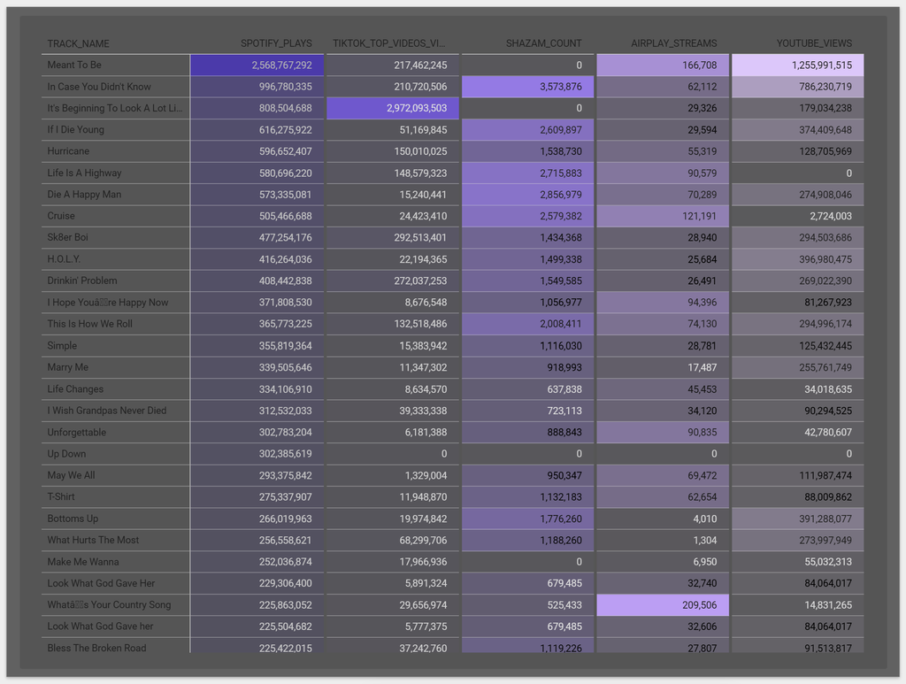

```python
image_path = "/content/drive/MyDrive/Colab Notebooks/rjs_Chartmetric_takehometest-dashboard.png"
display(Image(image_path))
```

Data prep for dashboard included below

I use the Llama3 model to generate a fun fact about each artist and the Spotify API to get the links to their Spotify artist pages. I stopped there as a proof of concept to prevent this from becoming overly long, but ideas for further development include using either to get genre information, generating headlines, retrieving artist images or album art, and more.

```python
# Groq (LLM) API Functions

def initialize_groq_client():
  """This function initializes and returns a Groq client with user data API key."""
  client = Groq(
      api_key=userdata.get("GROQ_API_KEY"),
  )
  return client

def get_artist_trivia(client, record):
    """This function generates and returns a piece of trivia using a groq call to Llama3, given a row with an ARTIST_NAME value."""
    chat_completion = client.chat.completions.create(
        messages=[
            {
                "role": "system",
                "content": "You are a well-read media journalist with a neutral tone. Answer concisely."
            },
            {
                "role": "user",
                "content": "What is a piece of niche trivia about "+record["ARTIST_NAME"],
            }
        ],
        model="llama3-8b-8192",
        temperature=0.75,
    )
    return chat_completion.choices[0].message.content
```

```python
# Spotify API Functions

def spotify_authenticate():
  """This function handles Spotify API authentication and returns the access token received. NOTE: This token expires after 1 hour (3600 seconds)."""
  ### Fetch authentication credentials
  client_id = userdata.get("SPOTIFY_CLIENT_ID")
  client_secret = userdata.get("SPOTIFY_CLIENT_SECRET")
  ### Encode credentials
  client_creds = f"{client_id}:{client_secret}"
  client_creds_b64 = base64.b64encode(client_creds.encode())
  response = requests.post("https://accounts.spotify.com/api/token",
                         headers={"Authorization": "Basic "+client_creds_b64.decode(),
                                  "Content-Type": "application/x-www-form-urlencoded"},
                         data={"grant_type": "client_credentials"}
  )
  access_token = json.loads(response.content.decode().replace("'", '"'))["access_token"]
  return access_token

def get_artist_from_track_search(token, title):
  """Search for track with given title and returns artist of first search result."""
  search_url = "https://api.spotify.com/v1/search?q="+title.replace(" ", "%")+"&type=track"
  response = requests.get(search_url,
                          headers={
                              "Authorization": "Bearer "+token
                              }
                          )
  if response.status_code == 200:
    return json.loads(response.content.decode())["tracks"]["items"][0]["album"]["artists"][0]["name"]
  else:
    print("Failed to retrieve data")
    return

def get_artist_link(token, record):
  """Search for an artist with given name and returns link to Spotify page."""
  search_url = "https://api.spotify.com/v1/search?q="+record["ARTIST_NAME"].replace(" ", "%")+"&type=artist"
  response = requests.get(search_url,
                          headers={
                              "Authorization": "Bearer "+token
                              }
                          )
  if response.status_code == 200:
    return json.loads(response.content.decode())["artists"]["items"][0]["external_urls"]["spotify"]
  else:
    print(record["ARTIST_NAME"]+"Failed to retrieve data")
    return
```

```python
# Track-Level Info

# Create a copy to avoid inadvertent changes to original dataset
tracks = Dataset.copy()

# Match the metric values to unique Track, Artist, and ISRC
tracks = tracks.groupby(["TRACK_NAME", "ARTIST_NAME", "ISRC"]).agg(
    {
    "UPC": "first",
    "ALBUM_NAME": "first",
    "CM_ID": "first",
    "YOUTUBE_VIEWS": "mean",
    "YOUTUBE_LIKES": "mean",
    "YOUTUBE_COMMENTS": "mean",
    "SOUNDCLOUD_PLAYS": "mean",
    "SPOTIFY_PLAYS": "mean",
    "SPOTIFY_POPULARITY": "mean",
    "SHAZAM_COUNT": "mean",
    "GENIUS_PAGEVIEWS": "mean",
    "TIKTOK_POSTS": "mean",
    "TIKTOK_TOP_VIDEOS_LIKES": "mean",
    "TIKTOK_TOP_VIDEOS_VIEWS": "mean",
    "PANDORA_LIFETIME_STREAMS": "mean",
    "AIRPLAY_STREAMS": "mean",
    "SIRIUSXM_STREAMS": "mean",
    "CM_TRACK_RANK": "mean",
    "TIDAL_POPULARITY": "mean",
    "YOUTUBE_VIEWS_WEEKLY_DIFF_PER": "mean",
    "YOUTUBE_LIKES_WEEKLY_DIFF_PER": "mean",
    "YOUTUBE_COMMENTS_WEEKLY_DIFF_PER": "mean",
    "SOUNDCLOUD_PLAYS_WEEKLY_DIFF_PER": "mean",
    "SPOTIFY_PLAYS_WEEKLY_DIFF_PER": "mean",
    "SPOTIFY_POPULARITY_WEEKLY_DIFF_PER": "mean",
    "SHAZAM_COUNT_WEEKLY_DIFF_PER": "mean",
    "GENIUS_PAGEVIEWS_WEEKLY_DIFF_PER": "mean",
    "TIKTOK_POSTS_WEEKLY_DIFF_PER": "mean",
    "TIKTOK_TOP_VIDEOS_LIKES_WEEKLY_DIFF_PER": "mean",
    "TIKTOK_TOP_VIDEOS_VIEWS_WEEKLY_DIFF_PER": "mean",
    "PANDORA_LIFETIME_STREAMS_WEEKLY_DIFF_PER": "mean",
    "AIRPLAY_STREAMS_WEEKLY_DIFF_PER": "mean",
    "SIRIUSXM_STREAMS_WEEKLY_DIFF_PER": "mean",
    "CM_TRACK_RANK_WEEKLY_DIFF_PER": "mean",
    "TIDAL_POPULARITY_WEEKLY_DIFF_PER": "mean",
    "YOUTUBE_VIEWS_MONTHLY_DIFF_PER": "mean",
    "YOUTUBE_LIKES_MONTHLY_DIFF_PER": "mean",
    "YOUTUBE_COMMENTS_MONTHLY_DIFF_PER": "mean",
    "SOUNDCLOUD_PLAYS_MONTHLY_DIFF_PER": "mean",
    "SPOTIFY_PLAYS_MONTHLY_DIFF_PER": "mean",
    "SPOTIFY_POPULARITY_MONTHLY_DIFF_PER": "mean",
    "SHAZAM_COUNT_MONTHLY_DIFF_PER" : "mean",
    "GENIUS_PAGEVIEWS_MONTHLY_DIFF_PER": "mean",
    "TIKTOK_POSTS_MONTHLY_DIFF_PER": "mean",
    "TIKTOK_TOP_VIDEOS_LIKES_MONTHLY_DIFF_PER": "mean",
    "TIKTOK_TOP_VIDEOS_VIEWS_MONTHLY_DIFF_PER": "mean",
    "PANDORA_LIFETIME_STREAMS_MONTHLY_DIFF_PER": "mean",
    "AIRPLAY_STREAMS_MONTHLY_DIFF_PER": "mean",
    "SIRIUSXM_STREAMS_MONTHLY_DIFF_PER": "mean",
    "CM_TRACK_RANK_MONTHLY_DIFF_PER": "mean",
    "TIDAL_POPULARITY_MONTHLY_DIFF_PER": "mean"
    }
)

# Match the metric values to unique Track and Artist
tracks = tracks.groupby(["TRACK_NAME", "ARTIST_NAME"]).agg(
    {
    "UPC": "first",
    "ALBUM_NAME": "first",
    "CM_ID": "first",
    "YOUTUBE_VIEWS": "sum",
    "YOUTUBE_LIKES": "sum",
    "YOUTUBE_COMMENTS": "sum",
    "SOUNDCLOUD_PLAYS": "sum",
    "SPOTIFY_PLAYS": "sum",
    "SPOTIFY_POPULARITY": "sum",
    "SHAZAM_COUNT": "sum",
    "GENIUS_PAGEVIEWS": "sum",
    "TIKTOK_POSTS": "sum",
    "TIKTOK_TOP_VIDEOS_LIKES": "sum",
    "TIKTOK_TOP_VIDEOS_VIEWS": "sum",
    "PANDORA_LIFETIME_STREAMS": "sum",
    "AIRPLAY_STREAMS": "sum",
    "SIRIUSXM_STREAMS": "sum",
    "CM_TRACK_RANK": "sum",
    "TIDAL_POPULARITY": "sum",
    "YOUTUBE_VIEWS_WEEKLY_DIFF_PER": "mean",
    "YOUTUBE_LIKES_WEEKLY_DIFF_PER": "mean",
    "YOUTUBE_COMMENTS_WEEKLY_DIFF_PER": "mean",
    "SOUNDCLOUD_PLAYS_WEEKLY_DIFF_PER": "mean",
    "SPOTIFY_PLAYS_WEEKLY_DIFF_PER": "mean",
    "SPOTIFY_POPULARITY_WEEKLY_DIFF_PER": "mean",
    "SHAZAM_COUNT_WEEKLY_DIFF_PER": "mean",
    "GENIUS_PAGEVIEWS_WEEKLY_DIFF_PER": "mean",
    "TIKTOK_POSTS_WEEKLY_DIFF_PER": "mean",
    "TIKTOK_TOP_VIDEOS_LIKES_WEEKLY_DIFF_PER": "mean",
    "TIKTOK_TOP_VIDEOS_VIEWS_WEEKLY_DIFF_PER": "mean",
    "PANDORA_LIFETIME_STREAMS_WEEKLY_DIFF_PER": "mean",
    "AIRPLAY_STREAMS_WEEKLY_DIFF_PER": "mean",
    "SIRIUSXM_STREAMS_WEEKLY_DIFF_PER": "mean",
    "CM_TRACK_RANK_WEEKLY_DIFF_PER": "mean",
    "TIDAL_POPULARITY_WEEKLY_DIFF_PER": "mean",
    "YOUTUBE_VIEWS_MONTHLY_DIFF_PER": "mean",
    "YOUTUBE_LIKES_MONTHLY_DIFF_PER": "mean",
    "YOUTUBE_COMMENTS_MONTHLY_DIFF_PER": "mean",
    "SOUNDCLOUD_PLAYS_MONTHLY_DIFF_PER": "mean",
    "SPOTIFY_PLAYS_MONTHLY_DIFF_PER": "mean",
    "SPOTIFY_POPULARITY_MONTHLY_DIFF_PER": "mean",
    "SHAZAM_COUNT_MONTHLY_DIFF_PER" : "mean",
    "GENIUS_PAGEVIEWS_MONTHLY_DIFF_PER": "mean",
    "TIKTOK_POSTS_MONTHLY_DIFF_PER": "mean",
    "TIKTOK_TOP_VIDEOS_LIKES_MONTHLY_DIFF_PER": "mean",
    "TIKTOK_TOP_VIDEOS_VIEWS_MONTHLY_DIFF_PER": "mean",
    "PANDORA_LIFETIME_STREAMS_MONTHLY_DIFF_PER": "mean",
    "AIRPLAY_STREAMS_MONTHLY_DIFF_PER": "mean",
    "SIRIUSXM_STREAMS_MONTHLY_DIFF_PER": "mean",
    "CM_TRACK_RANK_MONTHLY_DIFF_PER": "mean",
    "TIDAL_POPULARITY_MONTHLY_DIFF_PER": "mean"
    }
)

# Reset index after group_by()
tracks = tracks.reset_index()

# Output track data
tracks.to_csv('/content/drive/MyDrive/Colab Notebooks/tracks.csv',
               index=False)
```

```python
# Artist-Level Info

# Get unique artist names
artists = pd.DataFrame({"ARTIST_NAME": tracks["ARTIST_NAME"].unique(), "TRIVIA": None, "LINK": None})

# Set up APIs
client = initialize_groq_client()
token = spotify_authenticate()

# Find fun facts and links for each artist
# NOTE: The use of a for loop here is chosen for simplicity and readability. If scaled up, this should be optimized instead for efficiency.
for i in range(artists.shape[0]):
  artists.loc[i, "TRIVIA"] = get_artist_trivia(client, artists.iloc[i])
  artists.loc[i, "LINK"] = get_artist_link(token, artists.iloc[i])

# Output artist data
artists.to_csv('/content/drive/MyDrive/Colab Notebooks/artists.csv',
               index=False)

# Preview artist data
artists.head()
```

|  | ARTIST_NAME | TRIVIA | LINK |
| --- | --- | --- | --- |
| 0 | Ayron Jones | Ayron Jones, the American singer-songwriter, i... | https://open.spotify.com/artist/1iEaqWaYpKo9x0... |
| 1 | Jack Ingram | Jack Ingram, a country music singer-songwriter... | https://open.spotify.com/artist/7HNEfHmDlFofG6... |
| 2 | Payton Smith | Payton Smith, the American country music singe... | https://open.spotify.com/artist/4ZLKYFbf4KJWJR... |
| 3 | Trent Harmon | Trent Harmon, the winner of Season 15 of Ameri... | https://open.spotify.com/artist/1YSoHvvSAY0oOJ... |
| 4 | Nashville Cast | Nashville Cast, the musical group from the TV ... | https://open.spotify.com/artist/2NvmDZar6FF2CI... |